# Analysis for Rate Data

Kamarul Imran Musa Assoc Prof (Epidemiology and Statistics

2020-04-19

# 1 Prepare environment

- Create project
- Load library

```r
library(tidyverse)
library(broom)
library(janitor)
```

# 2 Read data

Now,

- Read a text data
- Names the columns/variables
- Transform ‘Number of Cases’ using log and name the column as ‘lcases’
- Add ‘lcases’ to the data

```r
credit <- read_table("creditcard.txt", col_names = c('income', 'cases', 'crcards')) #read txt
credit <- credit %>% mutate(lcases= log(cases))
```

# 3 Explore dataset

```r
glimpse(credit)
```

```
## Observations: 31
## Variables: 4
## $ income  <dbl> 24, 27, 28, 29, 30, 31, 32, 33, 34, 35, 38, 39, 40, 41, 42,...
## $ cases   <dbl> 1, 1, 5, 3, 9, 5, 8, 1, 7, 1, 3, 2, 5, 2, 2, 1, 1, 1, 10, 1...
## $ crcards <dbl> 0, 0, 2, 0, 1, 1, 0, 0, 1, 1, 1, 0, 0, 0, 0, 1, 0, 0, 2, 0,...
## $ lcases  <dbl> 0.0000000, 0.0000000, 1.6094379, 1.0986123, 2.1972246, 1.60...
```

# 4 Fit Poisson linear model

Use ‘lcases’ as the offset

```r
credit.m <- glm(crcards ~ income + offset(lcases), family = poisson, data = credit)
summary(credit.m)
```

```
##
## Call:
## glm(formula = crcards ~ income + offset(lcases), family = poisson,
##     data = credit)
##
## Deviance Residuals:
##     Min       1Q   Median       3Q      Max
## -1.6907  -0.9329  -0.5675   0.2186   2.1681
##
## Coefficients:
##              Estimate Std. Error z value Pr(>|z|)
## (Intercept) -2.386586   0.399655  -5.972 2.35e-09 ***
## income       0.020758   0.005165   4.019 5.84e-05 ***
## ---
## Signif. codes:  0 '***' 0.001 '**' 0.01 '*' 0.05 '.' 0.1 ' ' 1
##
## (Dispersion parameter for poisson family taken to be 1)
##
##     Null deviance: 42.078  on 30  degrees of freedom
## Residual deviance: 28.465  on 29  degrees of freedom
## AIC: 67.604
##
## Number of Fisher Scoring iterations: 5
```

# 5 Estimation

## 5.1 Estimate the 95% confidence interval for log rate

```r
tidy(credit.m, conf.int = TRUE)
```

```
## # A tibble: 2 x 7
##   term        estimate std.error statistic       p.value conf.low conf.high
##   <chr>          <dbl>     <dbl>     <dbl>         <dbl>    <dbl>     <dbl>
## 1 (Intercept)  -2.39     0.400       -5.97 0.00000000235  -3.21     -1.64
## 2 income        0.0208   0.00516      4.02 0.0000584       0.0102    0.0307
```

## 5.2 Estimate the incidence rate ratio (IRR)

```r
tidy(credit.m, exponentiate = TRUE, conf.int = TRUE)
```

```
## # A tibble: 2 x 7
##   term        estimate std.error statistic       p.value conf.low conf.high
##   <chr>          <dbl>     <dbl>     <dbl>         <dbl>    <dbl>     <dbl>
## 1 (Intercept)   0.0919   0.400       -5.97 0.00000000235   0.0403     0.195
## 2 income        1.02     0.00516      4.02 0.0000584       1.01       1.03
```

With 1 unit increase in INCOME the incidence rate increase for 1.021 or $2.1\%$.

# 6 Prediction

## 6.1 Predict the log rate for all data

Remember when the outcome is $log\frac{\mu}{t}$ or the log rate; then we can calculate by estimating

```r
credit.m2 <- augment(credit.m)
credit.m2
```

```
## # A tibble: 31 x 10
##    crcards income offset.lcases. .fitted .se.fit .resid   .hat .sigma .cooksd
##      <dbl>  <dbl>          <dbl>   <dbl>   <dbl>  <dbl>  <dbl>  <dbl>   <dbl>
##  1       0     24           0     -1.89    0.294 -0.550 0.0131  1.00  1.02e-3
##  2       0     27           0     -1.83    0.282 -0.568 0.0128  1.00  1.06e-3
##  3       2     28           1.61  -0.196   0.278  1.10  0.0636  0.985 6.12e-2
##  4       0     29           1.10  -0.686   0.274 -1.00  0.0379  0.990 1.03e-2
##  5       1     30           2.20   0.433   0.270 -0.467 0.113   1.00  1.37e-2
##  6       1     31           1.61  -0.134   0.267  0.131 0.0621  1.01  6.32e-4
##  7       0     32           2.08   0.357   0.263 -1.69  0.0987  0.950 8.68e-2
##  8       0     33           0     -1.70    0.259 -0.604 0.0122  1.00  1.14e-3
##  9       1     34           1.95   0.265   0.255 -0.277 0.0850  1.01  3.59e-3
## 10       1     35           0     -1.66    0.252  1.30  0.0120  0.977 2.13e-2
## # ... with 21 more rows, and 1 more variable: .std.resid <dbl>
```

Manually, we can

```r
log.oc<- -2.3866 + 0.02075*24
log.oc
```

```
## [1] -1.8886
```

The expected log rate is not meaningful. Remember that $log\frac{\mu}{t} = \beta_0 + \beta_1x_1 + ... + \beta_px_p$

## 6.2 Prediction for the expected log count and expected count

It is better to interpret using the expected log count or the expected count.

Let’s see the fitted count (Expected count) for observation 23 (where, Income=65 and log(t)=log(cases)=1.79).

Try calculate

1. the expected log of count for INCOME=65
2. the expected count for INCOME=65

## 6.3 Prediction for the expected log count

The expected log count

```r
#expected log count
log.count<- -2.3866+0.0208*65+1.79
log.count
```

```
## [1] 0.7554
```

```r
#is similar to
predict(credit.m, type = 'link')
```

```
##           1           2           3           4           5           6
## -1.88839820 -1.82612466 -0.19592891 -0.68599669  0.43337345 -0.13365537
##           7           8           9          10          11          12
##  0.35710610 -1.70157760  0.26509040 -1.66006191 -0.49917609 -0.88388335
##          13          14          15          16          17          18
##  0.05316523 -0.84236766 -0.82160982 -1.45248346 -1.39020993 -1.36945209
##          19          20          21          22          23          24
##  0.95389085 -1.30717855 -1.16187364  0.46832212  0.75443290  0.12355925
##          25          26          27          28          29          30
##  0.67590056 -0.74671675 -0.72595891 -0.64292753 -0.43534908  1.89611434
##          31
##  0.31193332
```

```r
predict(credit.m, type = 'link', se.fit = TRUE)
```

```
## $fit
##           1           2           3           4           5           6
## -1.88839820 -1.82612466 -0.19592891 -0.68599669  0.43337345 -0.13365537
##           7           8           9          10          11          12
##  0.35710610 -1.70157760  0.26509040 -1.66006191 -0.49917609 -0.88388335
##          13          14          15          16          17          18
##  0.05316523 -0.84236766 -0.82160982 -1.45248346 -1.39020993 -1.36945209
##          19          20          21          22          23          24
##  0.95389085 -1.30717855 -1.16187364  0.46832212  0.75443290  0.12355925
##          25          26          27          28          29          30
##  0.67590056 -0.74671675 -0.72595891 -0.64292753 -0.43534908  1.89611434
##          31
##  0.31193332
##
## $se.fit
##         1         2         3         4         5         6         7         8
## 0.2942469 0.2821328 0.2781692 0.2742457 0.2703639 0.2665257 0.2627329 0.2589875
##         9        10        11        12        13        14        15        16
## 0.2552917 0.2516476 0.2410490 0.2376356 0.2342863 0.2310039 0.2277913 0.2186030
##        17        18        19        20        21        22        23        24
## 0.2101564 0.2075217 0.2049832 0.2002096 0.1870681 0.1856901 0.1808664 0.1796996
##        25        26        27        28        29        30        31
## 0.1796613 0.1867001 0.1881760 0.1953374 0.2208104 0.3182527 0.3620636
##
## $residual.scale
## [1] 1
```

## 6.4 Prediction for the expected count

The expected count

```r
exp.count <- exp(log.count)
exp.count
```

```
## [1] 2.128463
```

```r
#is similar to
predict(credit.m, type = 'response')
```

```
##         1         2         3         4         5         6         7         8
## 0.1513140 0.1610364 0.8220707 0.5035881 1.5424521 0.8748915 1.4291875 0.1823956
##         9        10        11        12        13        14        15        16
## 1.3035488 0.1901272 0.6070306 0.4131753 1.0546039 0.4306896 0.4397232 0.2339885
##        17        18        19        20        21        22        23        24
## 0.2490230 0.2542462 2.5957899 0.2705824 0.3128994 1.5973118 2.1264053 1.1315170
##        25        26        27        28        29        30        31
## 1.9658025 0.4739200 0.4838604 0.5257510 0.6470388 6.6599658 1.3660636
```

```r
predict(credit.m, type = 'response', se.fit = TRUE)
```

```
## $fit
##         1         2         3         4         5         6         7         8
## 0.1513140 0.1610364 0.8220707 0.5035881 1.5424521 0.8748915 1.4291875 0.1823956
##         9        10        11        12        13        14        15        16
## 1.3035488 0.1901272 0.6070306 0.4131753 1.0546039 0.4306896 0.4397232 0.2339885
##        17        18        19        20        21        22        23        24
## 0.2490230 0.2542462 2.5957899 0.2705824 0.3128994 1.5973118 2.1264053 1.1315170
##        25        26        27        28        29        30        31
## 1.9658025 0.4739200 0.4838604 0.5257510 0.6470388 6.6599658 1.3660636
##
## $se.fit
##          1          2          3          4          5          6          7
## 0.04452367 0.04543365 0.22867478 0.13810687 0.41702342 0.23318105 0.37549453
##          8          9         10         11         12         13         14
## 0.04723817 0.33278520 0.04784506 0.14632410 0.09818514 0.24707921 0.09949097
##         15         16         17         18         19         20         21
## 0.10016514 0.05115057 0.05233379 0.05276160 0.53209330 0.05417319 0.05853350
##         22         23         24         25         26         27         28
## 0.29660502 0.38459534 0.20333312 0.35317861 0.08848091 0.09105089 0.10269884
##         29         30         31
## 0.14287288 2.11955194 0.49460189
##
## $residual.scale
## [1] 1
```

```r
#OR
credit.fit <- fitted(credit.m) # but fitted() does not give SE
credit.fit
```

```
##         1         2         3         4         5         6         7         8
## 0.1513140 0.1610364 0.8220707 0.5035881 1.5424521 0.8748915 1.4291875 0.1823956
##         9        10        11        12        13        14        15        16
## 1.3035488 0.1901272 0.6070306 0.4131753 1.0546039 0.4306896 0.4397232 0.2339885
##        17        18        19        20        21        22        23        24
## 0.2490230 0.2542462 2.5957899 0.2705824 0.3128994 1.5973118 2.1264053 1.1315170
##        25        26        27        28        29        30        31
## 1.9658025 0.4739200 0.4838604 0.5257510 0.6470388 6.6599658 1.3660636
```

# 7 Residuals

## 7.1 Residuals for default

```r
residuals(credit.m)
```

```
##          1          2          3          4          5          6          7
## -0.5501163 -0.5675146  1.0956485 -1.0035816 -0.4670732  0.1307432 -1.6906729
##          8          9         10         11         12         13         14
## -0.6039794 -0.2773388  1.3039855  0.4608832 -0.9090383 -1.4523112 -0.9281052
##         15         16         17         18         19         20         21
## -0.9377880  1.1717269 -0.7057238 -0.7130866 -0.3854933 -0.7356391 -0.7910744
##         22         23         24         25         26         27         28
##  0.3064701  2.1681166  1.4537374  0.6840142 -0.9735707 -0.9837280 -1.0254277
##         29         30         31
## -1.1375753 -0.2601404 -0.3290297
```

## 7.2 Residuals for expected count

These are the raw residuals

```r
residuals(credit.m, type = 'response')
```

```
##          1          2          3          4          5          6          7
## -0.1513140 -0.1610364  1.1779293 -0.5035881 -0.5424521  0.1251085 -1.4291875
##          8          9         10         11         12         13         14
## -0.1823956 -0.3035488  0.8098728  0.3929694 -0.4131753 -1.0546039 -0.4306896
##         15         16         17         18         19         20         21
## -0.4397232  0.7660115 -0.2490230 -0.2542462 -0.5957899 -0.2705824 -0.3128994
##         22         23         24         25         26         27         28
##  0.4026882  3.8735947  1.8684830  1.0341975 -0.4739200 -0.4838604 -0.5257510
##         29         30         31
## -0.6470388 -0.6599658 -0.3660636
```

```r
#for example, no 23 the observed = 6
#and the expected = 2.126
#so the residuals = 6-2.126-3.87
```

# 8 Plot predicted vs observed

```r
credit <- bind_cols(credit.m2, exp_crcards = credit.fit)
head(credit)
```

```
## # A tibble: 6 x 11
##   crcards income offset.lcases. .fitted .se.fit .resid   .hat .sigma .cooksd
##     <dbl>  <dbl>          <dbl>   <dbl>   <dbl>  <dbl>  <dbl>  <dbl>   <dbl>
## 1       0     24           0     -1.89    0.294 -0.550 0.0131  1.00  1.02e-3
## 2       0     27           0     -1.83    0.282 -0.568 0.0128  1.00  1.06e-3
## 3       2     28           1.61  -0.196   0.278  1.10  0.0636  0.985 6.12e-2
## 4       0     29           1.10  -0.686   0.274 -1.00  0.0379  0.990 1.03e-2
## 5       1     30           2.20   0.433   0.270 -0.467 0.113   1.00  1.37e-2
## 6       1     31           1.61  -0.134   0.267  0.131 0.0621  1.01  6.32e-4
## # ... with 2 more variables: .std.resid <dbl>, exp_crcards <dbl>
```

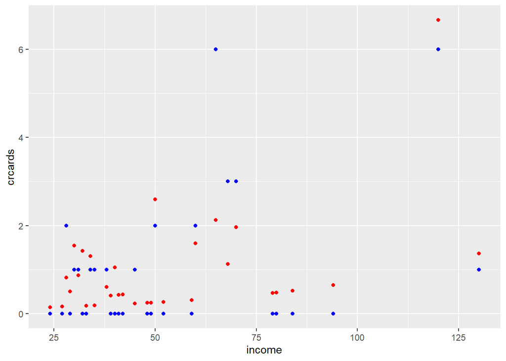

```r
ggplot(data = credit) + geom_point(aes(x = income, y = crcards), colour = 'blue') +
  geom_point(aes(x = income, y = exp_crcards), colour = 'red')
```

# 9 Getting more elaborate predictions

To calculate the expected count based on *augment*, do this (example for INCOME=65 observation 23)

```r
log.count23 <- -2.38658647 + 0.02075784*65 + 1.7917595
log.count23
```

```
## [1] 0.7544326
```

```r
#similar to .fitted for observation no 23. Then exp it to get the expected count
exp(log.count23)
```

```
## [1] 2.126405
```

The expected count (if income = 65 and obsrved cards = 6) is calculated from

$$log\frac{\mu}{t} = -2.3866 + 0.0208 \times 65$$
$$log(\mu) = -2.3866 + 0.0208 \times 65 + log(t)$$
$$log(\mu) = -2.3866 + 0.0208 \times 65 + log(6)$$
$$\mu = \exp(-2.3866 + 0.0208 \times 65 + 1.79176)$$

```r
exp(-2.3866 + 0.0208*65 + 1.79176)
```

```
## [1] 2.132212
```

The expected rate (if income = 65 and obsrved cards = 6) would be

$$log\frac{\mu}{t} = -2.3866 + 0.0208 \times 65$$

$$\frac{\mu}{t} = exp(-2.3866 + 0.0208 \times 65)$$

```r
exp(-2.3866 + 0.0208*65)
```

```
## [1] 0.3553685
```

# 10 New prediction

Let calculate the expected count for INCOME 25, 35, 45, 55, 65, 75 and 85 and cases equals 6

```r
log(6)
```

```
## [1] 1.791759
```

```r
new.data<-data.frame(income=c(25, 35, 45, 55, 65, 75,85), lcases = log(6))
new.data
```

```
##   income   lcases
## 1     25 1.791759
## 2     35 1.791759
## 3     45 1.791759
## 4     55 1.791759
## 5     65 1.791759
## 6     75 1.791759
## 7     85 1.791759
```

```r
predict(credit.m, newdata = new.data, type = 'response')
```

```
##         1         2         3         4         5         6         7
## 0.9269266 1.1407633 1.4039308 1.7278096 2.1264053 2.6169548 3.2206712
```

So the expected count for INCOME equals 25, 35, 45, 55, 65, 75 and 85 with cases equals 6, are 0.9269271 1.1407639 1.4039315 1.7278105 2.1264064 2.6169562 3.2206729, respectively.

# 11 References

1. https://denishaine.wordpress.com/2013/05/10/veterinary-epidemiologic-research-count-and-rate-data-poisson-regression-and-risk-ratios/
2. https://onlinecourses.science.psu.edu/stat504/node/170
3. https://cran.r-project.org/web/packages/pscl/vignettes/countreg.pdf
4. http://www.ats.ucla.edu/stat/stata/output/stata_poisson_output.htm
5. Diagnostic . http://stats.stackexchange.com/questions/70558/diagnostic-plots-for-count-regression